# Calculating Non-Dementia Mortality

Sigal Maya

Updated 02-20-2025

The model utilizes the risk ratio for mortality to evaluate the increased risk for death among those with dementia. However, using the risk ratio in conjunction with all-cause mortality inflates overall mortality in the model. We thus estimated the non-dementia-related mortality rate (i.e, mortality among those without the risk factor) by subtracting dementia-related deaths from all-cause deaths at each age. All-cause and dementia-related death rates were obtained from the CDC Wonder database.

Rates for older ages (85+) were unavailable, so we extrapolated using available data. First, we visually inspected the data to examine the distribution by age, confirming that the rate grew exponentially with age:

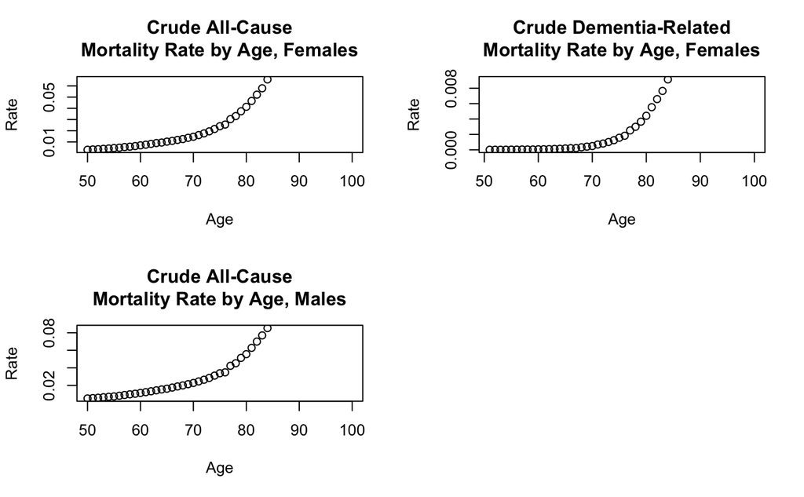

We used a log-transformed linear model with age as the predictor variable to extrapolate all-cause mortality rates up to the age of 100 (the maximum age allowed in the microsimulation). Initial models using all data points resulted in predictions that were not smooth, thus we used rates for ages 76 and up for predictions. The `predict()` function in R was used to predict the missing estimates, which were then exponentiated to obtain rates. Data were visually inspected to confirm a smooth and uninterrupted exponential increase in all-cause mortality rate with age.

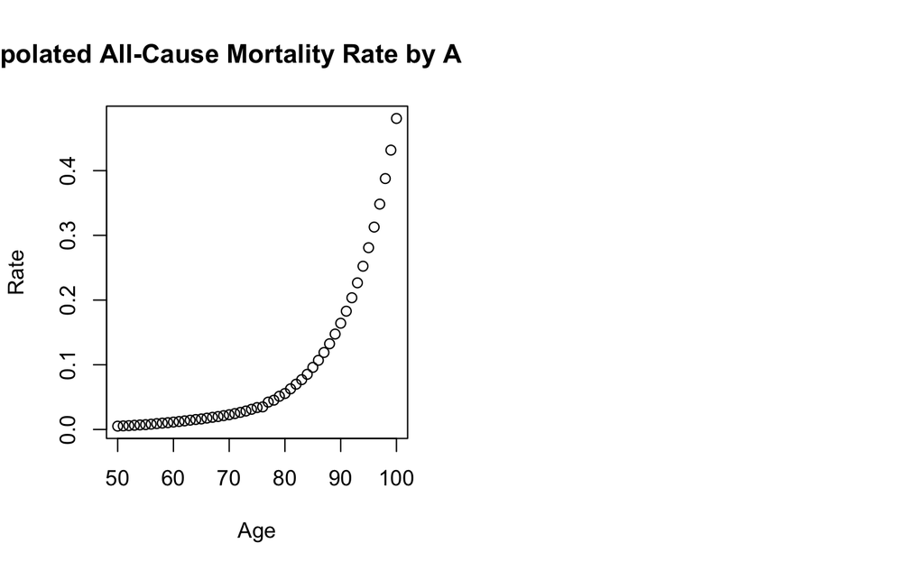

Next, we calculated non-dementia-related mortality rates by subtracting dementia-related mortality rates from all-cause mortality rates. We fit another log-transformed linear model to the non-dementia-related mortality rates to obtain missing values for ages 85 and up.

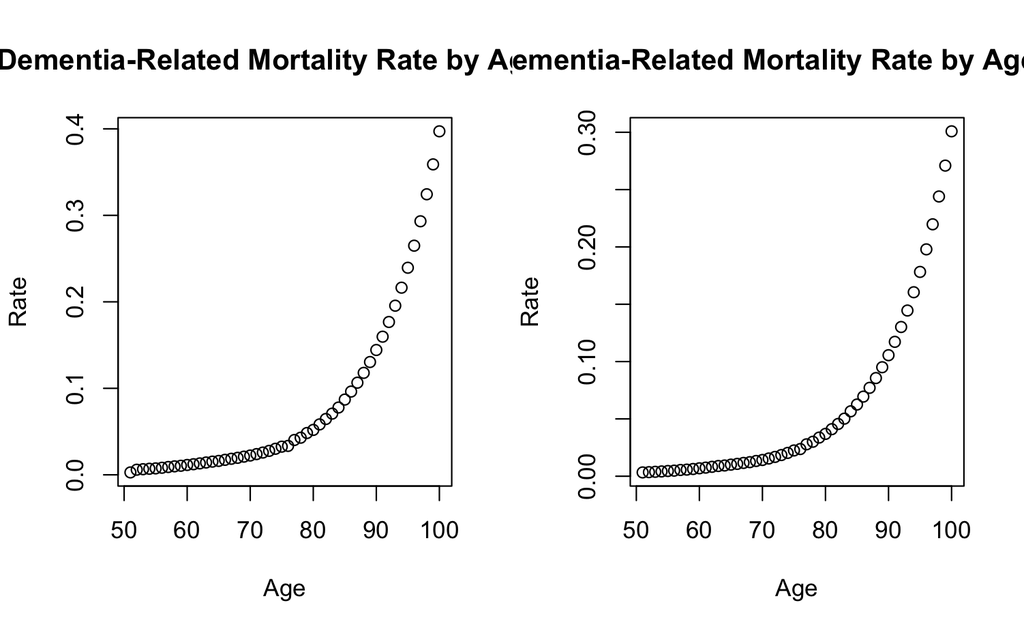

Finally, we converted rates to probabilities using the equation $\text{probability} = 1 - e^{-\text{rate}}$.